# Final Project Presentation

Electronic Pediatric Early Warning Score

Javier Rojas  
MS Candidate in Big Data Analytics  
CIS627 - Big Data Analytics Capstone

# Outline

- Background information related to this project
- Project aim or problem
- Potential and proposed solutions
- Datasets used
- Methods implemented
- Future work
- Conclusion
- References

# Background information related to this project

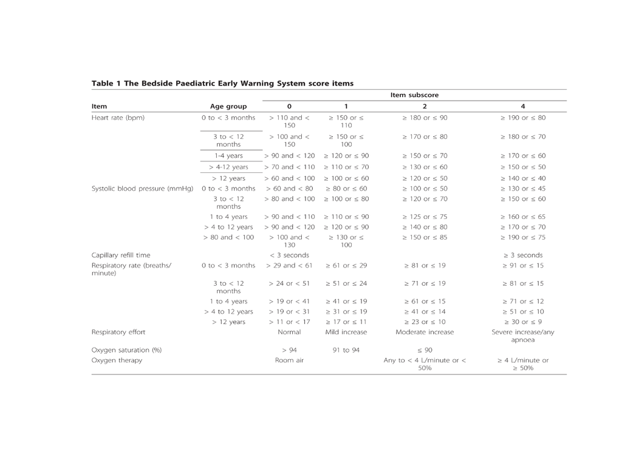

- Based on the literature, it has been denoted that a score of five or more has been associated with an increased propability in Code Blue events occurring; as such, this was accounted for in this project.
- Nonetheless, most PEWS used today have low sensitivity and are labor intensive. Thus, there is the need for an early warning system that can help improve communication between the nursing staff and physicians and can help identify a higher risk patient population more effectively and efficiently.

# Project aim or problem

- Improve the existing PEWS system’s sensitivity of early warning scores by applying statistics, sub sampling and machine learning into the analysis of raw patient data, which contains their vital signs, lab results and diagnostics.
- To accomplish such goal, I intend to construct a machine learning algorithm, which can serve as an automated scoring system with a higher sensitivity than the current PEWS in identifying patients at risk of entering Code Blue in a timely manner.

# Potential and proposed solutions

- For prepping the data for analysis, using R’s tidyverse package functions such as filtering, selecting, mutating, grouping, slicing and arranging along with the pipe %>% operator for applying the exclusion criteria intended.
- Implementing Support Vector Machine or Logistic Regression by using the caret (classification and regression training) and e1071 (support vector machine) package for the problem in question.
- Applying 10-fold cross validation through the caret package’s “trainControl()” function for defining the rule for model training and the conditions around how sampling and grid search is to be done.
- Calling the package’s “train()” function for evaluating the model using the cross-validation and resampling metrics specified in the “trainControl” to measure the effect of tuning these parameters in performance.
- Next, relying on the ROCR package for calculating the Area Under the Curve (AUC) and to create the Receiver Operating Curve (ROC) through functions such as “predict()” for producing predicted values from the model in question, “prediction()” function for extracting the predicted values via “predict()” from a model object and return a data frame and “performance()” for creating performance objects and performing various types of predictor evaluations.
- Lastly, using a “ggplot()” object created by ggplot2 library and plotROC library to plot the ROC curve.

# Dataset

- Based on applying the exclusion criterias considered toward the original dataset, I obtained the following 40-sample toy matrix.

```
## # A tibble: 40 × 182
##        MRN VS_1t_1 VS_2t_1 VS_3t_1 VS_4t_1 VS_5t_1 VS_6t_1 VS_1t_2 VS_2t_2
##      <int>   <int>   <int>   <dbl>   <int>   <int>   <int>   <int>   <int>
## 1  1023323      64      99    98.7      94     110      26      73     113
## 2  1028322      82     123    98.4     100      77      22      75     117
## 3  1129490      85     106    97.9      95     147      22      80     121
## 4  1130377      71     102    98.1      98     101      26      76     127
## 5  1137850      67     107    97.8     100     107      25      67     107
## 6  1177721      79     113    98.2      98      96      20      82     116
## 7  1186850      65      99    97.0     100      68      20      52      91
## 8  1225722      48      98    36.1     100     108      24      68      96
## 9  1258815      58      97    97.7     100      88      18      58      97
## 10 1259031      62     102   101.3      98     128      24      56      89
## # ... with 30 more rows, and 173 more variables: VS_3t_2 <dbl>,
## #   VS_4t_2 <int>, VS_5t_2 <int>, VS_6t_2 <int>, VS_1t_3 <int>,
## #   VS_2t_3 <int>, VS_3t_3 <dbl>, VS_4t_3 <int>, VS_5t_3 <int>,
## #   VS_6t_3 <int>, VS_1t_4 <int>, VS_2t_4 <int>, VS_3t_4 <dbl>,
## #   VS_4t_4 <int>, VS_5t_4 <int>, VS_6t_4 <int>, VS_1t_5 <int>,
## #   VS_2t_5 <int>, VS_3t_5 <dbl>, VS_4t_5 <int>, VS_5t_5 <int>,
## #   VS_6t_5 <int>, VS_1t_6 <int>, VS_2t_6 <int>, VS_3t_6 <dbl>,
## #   VS_4t_6 <int>, VS_5t_6 <int>, VS_6t_6 <int>, VS_1t_7 <int>,
## #   VS_2t_7 <int>, VS_3t_7 <dbl>, VS_4t_7 <int>, VS_5t_7 <int>,
## #   VS_6t_7 <int>, VS_1t_8 <int>, VS_2t_8 <int>, VS_3t_8 <dbl>,
## #   VS_4t_8 <int>, VS_5t_8 <int>, VS_6t_8 <int>, VS_1t_9 <int>,
## #   VS_2t_9 <int>, VS_3t_9 <dbl>, VS_4t_9 <int>, VS_5t_9 <int>,
## #   VS_6t_9 <int>, VS_1t_10 <int>, VS_2t_10 <int>, VS_3t_10 <dbl>,
## #   VS_4t_10 <int>, VS_5t_10 <int>, VS_6t_10 <int>, VS_1t_11 <int>,
## #   VS_2t_11 <int>, VS_3t_11 <dbl>, VS_4t_11 <int>, VS_5t_11 <int>,
## #   VS_6t_11 <int>, VS_1t_12 <int>, VS_2t_12 <int>, VS_3t_12 <dbl>,
## #   VS_4t_12 <int>, VS_5t_12 <int>, VS_6t_12 <int>, VS_1t_13 <int>,
## #   VS_2t_13 <int>, VS_3t_13 <dbl>, VS_4t_13 <int>, VS_5t_13 <int>,
## #   VS_6t_13 <int>, VS_1t_14 <int>, VS_2t_14 <int>, VS_3t_14 <dbl>,
## #   VS_4t_14 <int>, VS_5t_14 <int>, VS_6t_14 <int>, VS_1t_15 <int>,
## #   VS_2t_15 <int>, VS_3t_15 <dbl>, VS_4t_15 <int>, VS_5t_15 <int>,
## #   VS_6t_15 <int>, VS_1t_16 <int>, VS_2t_16 <int>, VS_3t_16 <dbl>,
## #   VS_4t_16 <int>, VS_5t_16 <int>, VS_6t_16 <int>, VS_1t_17 <int>,
## #   VS_2t_17 <int>, VS_3t_17 <dbl>, VS_4t_17 <int>, VS_5t_17 <int>,
## #   VS_6t_17 <int>, VS_1t_18 <int>, VS_2t_18 <int>, VS_3t_18 <dbl>,
## #   VS_4t_18 <int>, VS_5t_18 <int>, VS_6t_18 <int>, ...
```

# Methods

- I proceeded with applying machine learning models that can possibly detect with high accuracy those patients that are labeled either “normal” or “worst”, which consisted of a binary classification problem.

*SVM*

```
## Confusion Matrix and Statistics
##
##           Reference
## Prediction Normal Worst
##     Normal     14     7
##     Worst       8    11
##
##                Accuracy : 0.625
##                  95% CI : (0.458, 0.7727)
##     No Information Rate : 0.55
##     P-Value [Acc > NIR] : 0.2142
##
##                   Kappa : 0.2462
##  Mcnemar's Test P-Value : 1.0000
##
##             Sensitivity : 0.6111
##             Specificity : 0.6364
##          Pos Pred Value : 0.5789
##          Neg Pred Value : 0.6667
##              Prevalence : 0.4500
##          Detection Rate : 0.2750
##    Detection Prevalence : 0.4750
##       Balanced Accuracy : 0.6237
##
##        'Positive' Class : Worst
##
```

*LR*

```
## Confusion Matrix and Statistics
##
##           Reference
## Prediction Normal Worst
##     Normal     11     8
##     Worst      11    10
##
##                Accuracy : 0.525
##                  95% CI : (0.3613, 0.6849)
##     No Information Rate : 0.55
##     P-Value [Acc > NIR] : 0.6844
##
##                   Kappa : 0.0547
##  Mcnemar's Test P-Value : 0.6464
##
##             Sensitivity : 0.5556
##             Specificity : 0.5000
##          Pos Pred Value : 0.4762
##          Neg Pred Value : 0.5789
##              Prevalence : 0.4500
##          Detection Rate : 0.2500
##    Detection Prevalence : 0.5250
##       Balanced Accuracy : 0.5278
##
##        'Positive' Class : Worst
##
```

# Methods (cont.)

```
## Confusion Matrix and Statistics
##
##           Reference
## Prediction Normal Worst
##     Normal     27     2
##     Worst       2     9
##
##                Accuracy : 0.9
##                  95% CI : (0.7634, 0.9721)
##     No Information Rate : 0.725
##     P-Value [Acc > NIR] : 0.006632
##
##                   Kappa : 0.7492
##  Mcnemar's Test P-Value : 1.000000
##
##             Sensitivity : 0.8182
##             Specificity : 0.9310
##          Pos Pred Value : 0.8182
##          Neg Pred Value : 0.9310
##              Prevalence : 0.2750
##          Detection Rate : 0.2250
##    Detection Prevalence : 0.2750
##       Balanced Accuracy : 0.8746
##
##        'Positive' Class : Worst
##
```

```
## Confusion Matrix and Statistics
##
##           Reference
## Prediction Normal Worst
##     Normal     12     5
##     Worst      17     6
##
##                Accuracy : 0.45
##                  95% CI : (0.2926, 0.6151)
##     No Information Rate : 0.725
##     P-Value [Acc > NIR] : 0.99994
##
##                   Kappa : -0.0304
##  Mcnemar's Test P-Value : 0.01902
##
##             Sensitivity : 0.5455
##             Specificity : 0.4138
##          Pos Pred Value : 0.2609
##          Neg Pred Value : 0.7059
##              Prevalence : 0.2750
##          Detection Rate : 0.1500
##    Detection Prevalence : 0.5750
##       Balanced Accuracy : 0.4796
##
##        'Positive' Class : Worst
##
```

# Dataset (cont.)

- Although these results were promising, I wanted to validate with a larger dataset to obtain a larger training dataset to work with and compare both proposed and constructed models against this new dataset to determine which is the best to proceed with.

```
## # A tibble: 8,217 × 183
##    Patient.ID VS_1t_1 VS_2t_1 VS_3t_1 VS_4t_1 VS_5t_1 VS_6t_1 VS_1t_2
##         <int>   <int>   <int>   <dbl>   <dbl>   <int>   <int>   <int>
## 1      835205      72     119    98.1     100      98      18      85
## 2     1127414      67     108    97.9      85      80      24      67
## 3     1224603      82     132    98.5      99      82      20      82
## 4      948156      73     105   100.4     100      77      19      73
## 5     1067551      59      94    98.4     100      88      18      59
## 6      775157      83     125    97.9      97     103      18      83
## 7    60081351      67     101    98.0      99      71      20      62
## 8     1057692      55      86    97.5      99     129      24      55
## 9     1285366      68     104    98.2      99     121      22      49
## 10     941231      74     121    36.3     100     120      16      78
## # ... with 8,207 more rows, and 175 more variables: VS_2t_2 <int>,
## #   VS_3t_2 <dbl>, VS_4t_2 <dbl>, VS_5t_2 <int>, VS_6t_2 <int>,
## #   VS_1t_3 <int>, VS_2t_3 <int>, VS_3t_3 <dbl>, VS_4t_3 <dbl>,
## #   VS_5t_3 <int>, VS_6t_3 <int>, VS_1t_4 <int>, VS_2t_4 <int>,
## #   VS_3t_4 <dbl>, VS_4t_4 <dbl>, VS_5t_4 <int>, VS_6t_4 <int>,
## #   VS_1t_5 <int>, VS_2t_5 <int>, VS_3t_5 <dbl>, VS_4t_5 <dbl>,
## #   VS_5t_5 <int>, VS_6t_5 <int>, VS_1t_6 <int>, VS_2t_6 <int>,
## #   VS_3t_6 <dbl>, VS_4t_6 <dbl>, VS_5t_6 <int>, VS_6t_6 <int>,
## #   VS_1t_7 <int>, VS_2t_7 <int>, VS_3t_7 <dbl>, VS_4t_7 <dbl>,
## #   VS_5t_7 <int>, VS_6t_7 <int>, VS_1t_8 <int>, VS_2t_8 <int>,
## #   VS_3t_8 <dbl>, VS_4t_8 <dbl>, VS_5t_8 <int>, VS_6t_8 <int>,
## #   VS_1t_9 <int>, VS_2t_9 <int>, VS_3t_9 <dbl>, VS_4t_9 <dbl>,
## #   VS_5t_9 <int>, VS_6t_9 <int>, VS_1t_10 <int>, VS_2t_10 <int>,
## #   VS_3t_10 <dbl>, VS_4t_10 <dbl>, VS_5t_10 <int>, VS_6t_10 <int>,
## #   VS_1t_11 <int>, VS_2t_11 <int>, VS_3t_11 <dbl>, VS_4t_11 <dbl>,
## #   VS_5t_11 <int>, VS_6t_11 <int>, VS_1t_12 <int>, VS_2t_12 <int>,
## #   VS_3t_12 <dbl>, VS_4t_12 <dbl>, VS_5t_12 <int>, VS_6t_12 <int>,
## #   VS_1t_13 <int>, VS_2t_13 <int>, VS_3t_13 <dbl>, VS_4t_13 <dbl>,
## #   VS_5t_13 <int>, VS_6t_13 <int>, VS_1t_14 <int>, VS_2t_14 <int>,
## #   VS_3t_14 <dbl>, VS_4t_14 <dbl>, VS_5t_14 <int>, VS_6t_14 <int>,
## #   VS_1t_15 <int>, VS_2t_15 <int>, VS_3t_15 <dbl>, VS_4t_15 <dbl>,
## #   VS_5t_15 <int>, VS_6t_15 <int>, VS_1t_16 <int>, VS_2t_16 <int>,
## #   VS_3t_16 <dbl>, VS_4t_16 <dbl>, VS_5t_16 <int>, VS_6t_16 <int>,
## #   VS_1t_17 <int>, VS_2t_17 <int>, VS_3t_17 <dbl>, VS_4t_17 <dbl>,
## #   VS_5t_17 <int>, VS_6t_17 <int>, VS_1t_18 <int>, VS_2t_18 <int>,
## #   VS_3t_18 <dbl>, VS_4t_18 <dbl>, VS_5t_18 <int>, ...
```

- However, I came to the realization that I have an unbalanced training data were almost all the patients were considered “normal” and slim were considered “worst”.

```
##
##    Normal     Worst
## 0.9889254 0.0110746
```

# Methods (cont.)

# Statistical Results

- By considering the previously mentioned scenarios, I compared both models specifically with the “Manual” and “ROSE” sampling and for one of the age groups, which pertains to the school-age (6-11yr) group.
- We can observe in the following results that applying “ROSE” sampling to the data significantly improved the heavily imbalanced distribution encountered originally.

```
## # A tibble: 1,709 × 182
##    VS_1t_1 VS_2t_1 VS_3t_1 VS_4t_1 VS_5t_1 VS_6t_1 VS_1t_2 VS_2t_2 VS_3t_2
##      <int>   <int>   <dbl>   <dbl>   <int>   <int>   <int>   <int>   <dbl>
## 1       67     108    97.9      85      80      24      67     108    97.9
## 2       82     132    98.5      99      82      20      82     132    98.5
## 3       67     101    98.0      99      71      20      62     110    98.0
## 4       55      86    97.5      99     129      24      55      86    97.5
## 5       91     103    97.4      98     107      18      91     103    97.8
## 6       70     109    98.1      99      96      20      63     102    99.0
## 7       64      99    98.2     100     130      18      64      99    98.2
## 8       59      96    98.0      99      91      20      60      97    98.2
## 9       66     102    98.4     100      67      18      66     102    98.4
## 10      53      90    97.8      93     100      24      53      90    97.8
## # ... with 1,699 more rows, and 173 more variables: VS_4t_2 <dbl>,
## #   VS_5t_2 <int>, VS_6t_2 <int>, VS_1t_3 <int>, VS_2t_3 <int>,
## #   VS_3t_3 <dbl>, VS_4t_3 <dbl>, VS_5t_3 <int>, VS_6t_3 <int>,
## #   VS_1t_4 <int>, VS_2t_4 <int>, VS_3t_4 <dbl>, VS_4t_4 <dbl>,
## #   VS_5t_4 <int>, VS_6t_4 <int>, VS_1t_5 <int>, VS_2t_5 <int>,
## #   VS_3t_5 <dbl>, VS_4t_5 <dbl>, VS_5t_5 <int>, VS_6t_5 <int>,
## #   VS_1t_6 <int>, VS_2t_6 <int>, VS_3t_6 <dbl>, VS_4t_6 <dbl>,
## #   VS_5t_6 <int>, VS_6t_6 <int>, VS_1t_7 <int>, VS_2t_7 <int>,
## #   VS_3t_7 <dbl>, VS_4t_7 <dbl>, VS_5t_7 <int>, VS_6t_7 <int>,
## #   VS_1t_8 <int>, VS_2t_8 <int>, VS_3t_8 <dbl>, VS_4t_8 <dbl>,
## #   VS_5t_8 <int>, VS_6t_8 <int>, VS_1t_9 <int>, VS_2t_9 <int>,
## #   VS_3t_9 <dbl>, VS_4t_9 <dbl>, VS_5t_9 <int>, VS_6t_9 <int>,
## #   VS_1t_10 <int>, VS_2t_10 <int>, VS_3t_10 <dbl>, VS_4t_10 <dbl>,
## #   VS_5t_10 <int>, VS_6t_10 <int>, VS_1t_11 <int>, VS_2t_11 <int>,
## #   VS_3t_11 <dbl>, VS_4t_11 <dbl>, VS_5t_11 <int>, VS_6t_11 <int>,
## #   VS_1t_12 <int>, VS_2t_12 <int>, VS_3t_12 <dbl>, VS_4t_12 <dbl>,
## #   VS_5t_12 <int>, VS_6t_12 <int>, VS_1t_13 <int>, VS_2t_13 <int>,
## #   VS_3t_13 <dbl>, VS_4t_13 <dbl>, VS_5t_13 <int>, VS_6t_13 <int>,
## #   VS_1t_14 <int>, VS_2t_14 <int>, VS_3t_14 <dbl>, VS_4t_14 <dbl>,
## #   VS_5t_14 <int>, VS_6t_14 <int>, VS_1t_15 <int>, VS_2t_15 <int>,
## #   VS_3t_15 <dbl>, VS_4t_15 <dbl>, VS_5t_15 <int>, VS_6t_15 <int>,
## #   VS_1t_16 <int>, VS_2t_16 <int>, VS_3t_16 <dbl>, VS_4t_16 <dbl>,
## #   VS_5t_16 <int>, VS_6t_16 <int>, VS_1t_17 <int>, VS_2t_17 <int>,
## #   VS_3t_17 <dbl>, VS_4t_17 <dbl>, VS_5t_17 <int>, VS_6t_17 <int>,
## #   VS_1t_18 <int>, VS_2t_18 <int>, VS_3t_18 <dbl>, VS_4t_18 <dbl>,
## #   VS_5t_18 <int>, VS_6t_18 <int>, VS_1t_19 <int>, ...
```

```
##
##    Normal     Worst
## 0.4839087 0.5160913
```

- The following table summary was obtained upon comparing both models’ overall accuracies and `kappa`, which is a measure of how well the model’s predictions agrees with the true values.
- One common interpretation of the `kappa` statistic is summarized as follows:
1. Poor agreement = less than 0.20
2. Fair agreement = 0.20 to 0.40
3. Moderate agreement = 0.40 to 0.60
4. Good agreement = 0.60 to 0.80
5. Very good agreement = 0.80 to 1.00

*Manual Balancing*

```
##
## Call:
## summary.resamples(object = resultsa)
##
## Models: LR, SVM
## Number of resamples: 30
##
## Accuracy
##       Min. 1st Qu. Median   Mean 3rd Qu. Max. NA's
## LR  0.9532  0.9825 0.9883 0.9864  0.9942    1    0
## SVM 0.9825  0.9883 0.9941 0.9916  0.9942    1    0
##
## Kappa
##          Min.   1st Qu.    Median   Mean 3rd Qu.   Max. NA's
## LR  -0.010340 -0.007859 -0.005882 0.1082       0 0.6640    2
## SVM -0.007859 -0.005882  0.000000 0.0156       0 0.4956    3
```

*ROSE sampling*

```
##
## Call:
## summary.resamples(object = resultsb)
##
## Models: LR, SVM
## Number of resamples: 30
##
## Accuracy
##       Min. 1st Qu. Median   Mean 3rd Qu.   Max. NA's
## LR  0.8363  0.8772 0.8921 0.8925  0.9104 0.9593    0
## SVM 0.8480  0.8889 0.8977 0.8982  0.9104 0.9415    0
##
## Kappa
##       Min. 1st Qu. Median   Mean 3rd Qu.   Max. NA's
## LR  0.6720  0.7544 0.7842 0.7850  0.8200 0.9185    0
## SVM 0.6952  0.7777 0.7949 0.7961  0.8209 0.8831    0
```

# Visual Results

```
## Confusion Matrix and Statistics
##
##           Reference
## Prediction Normal Worst
##     Normal    793    24
##     Worst      34   858
##
##                Accuracy : 0.9661
##                  95% CI : (0.9563, 0.9741)
##     No Information Rate : 0.5161
##     P-Value [Acc > NIR] : <2e-16
##
##                   Kappa : 0.932
##  Mcnemar's Test P-Value : 0.2373
##
##             Sensitivity : 0.9728
##             Specificity : 0.9589
##          Pos Pred Value : 0.9619
##          Neg Pred Value : 0.9706
##              Prevalence : 0.5161
##          Detection Rate : 0.5020
##    Detection Prevalence : 0.5219
##       Balanced Accuracy : 0.9658
##
##        'Positive' Class : Worst
##
```

*LR (ROC & AUC)*

```
## The Area Under ROC curve for this model is  0.9658383
```

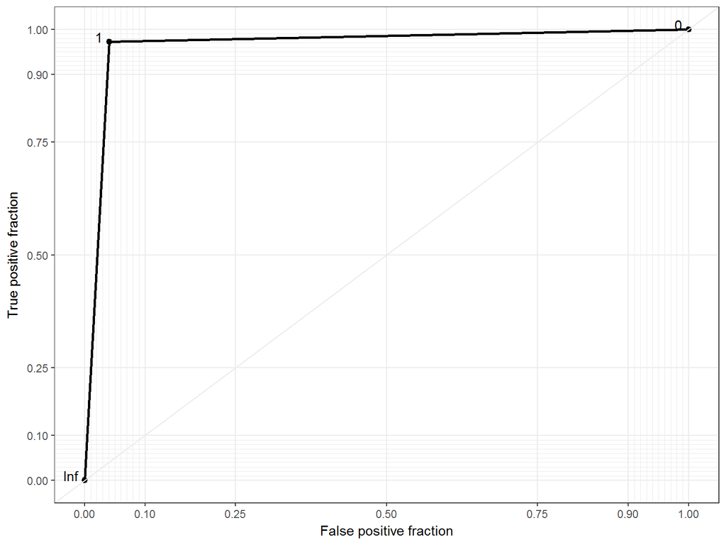

- Here are the following summary results I obtained by applying my LR model to all age groups:

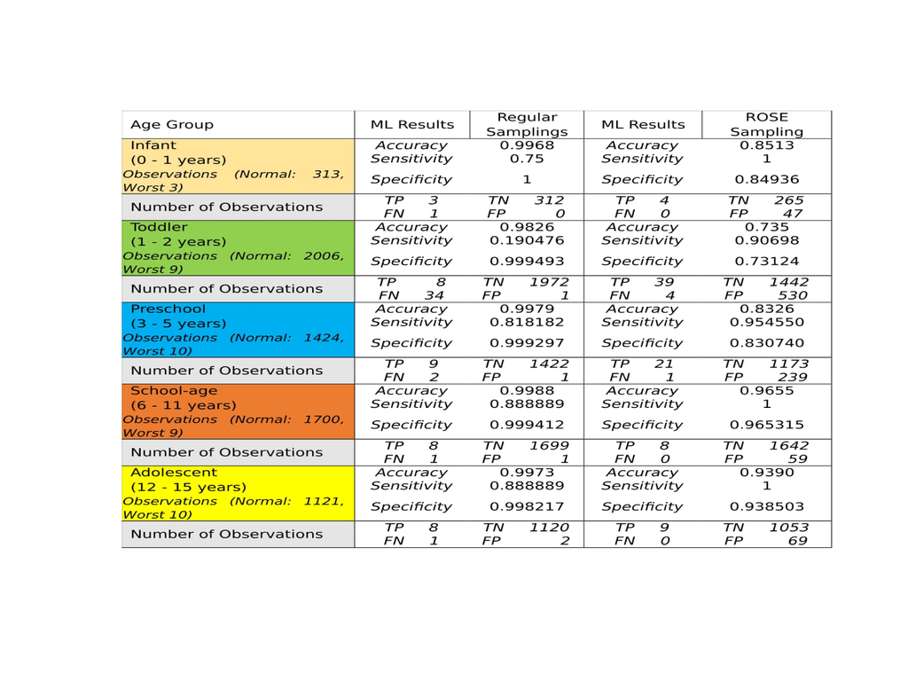

*Table 1: The results in the table above correspond to the best ML results for each age group based on the thresholds for PEWS that were considered in terms of sensitivity obtained. These results also correspond to the implemented Logistic Regression model. TP and FN stand for true positives (number of correctly classified positives “worst”) and false negatives (number of incorrectly classified positives “worst”); whereas, TN and FP stand for true negatives (number of correctly classified negatives “normal”) and false positives (number of incorrectly classified negatives “normal”).*

“ROC 1 (Manual - Best)”

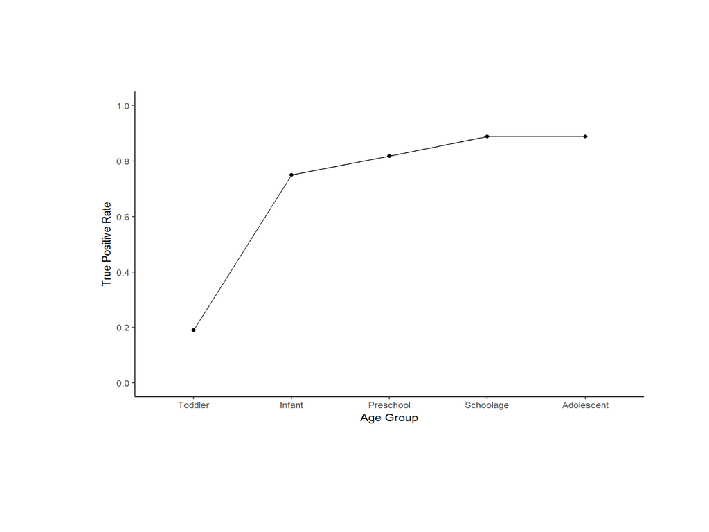

*Figure 1: Displaying the best corresponding true positive rates for each of the age groups in ascending order in the form of an “ROC” curve.*

“Accuracy 1 (Manual - Best)”

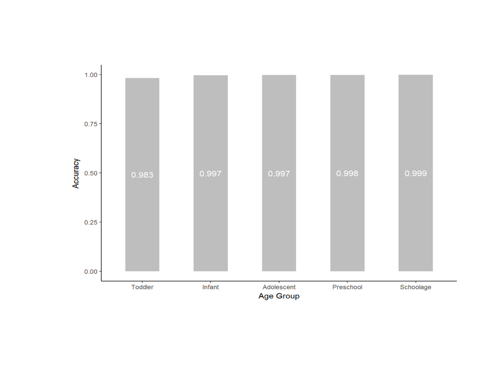

*Figure 2: Displaying the best corresponding accuracies for each of the age groups in ascending order in the form of a bar plot.*

“ROC 2 (ROSE - Best)”

[figure not shown]

*Figure 3: Displaying the best corresponding true positive rates for each of the age groups in ascending order in the form of an “ROC” curve.*

“Accuracy 2 (ROSE - Best)”

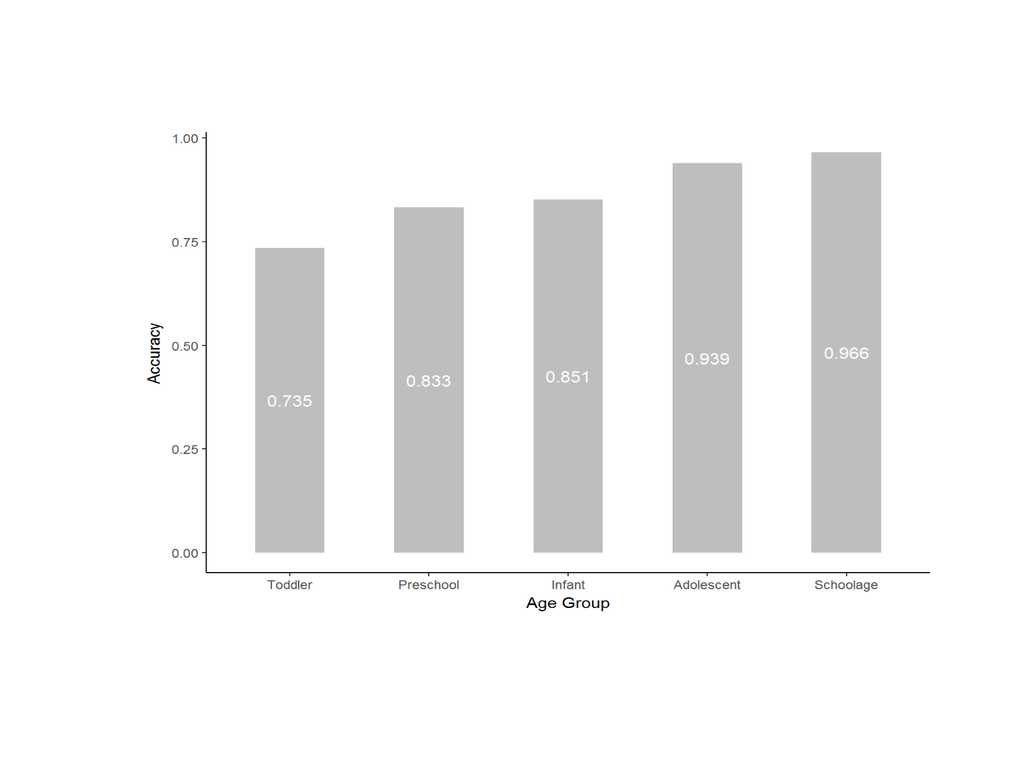

*Figure 4: Displaying the best corresponding accuracies for each of the age groups in ascending order in the form of a bar plot.*

# Progress made toward future work implementation

- The current results that have been demonstrated have been promosing in terms of correctly classifying those patients considered “normal” or “worst”. Nonetheless, there still remains the task of analyzing the factor of time, which corresponds, in this case, to the moment each patient’s observation was recorded.
- To start accomplishing such task, I took one patient who had suffered from cardiac arrest and considered those vital signs that have a high correlation between each other based on the correlogram created below:

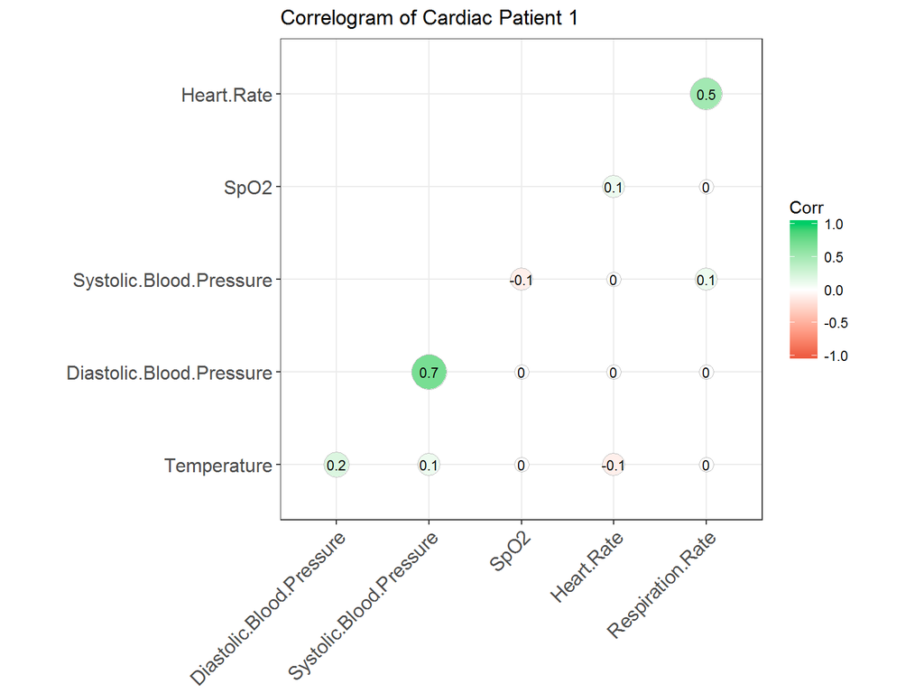

- Once these vital signs were determined, I plotted the results with the help of the `qcc (Quality Control Chart)` function in R, which will flag runs in each of the vital sign results for violating `Nelson Rules`, which consists of a set of eight decision rules for detecting “out-of-control” or non-random conditions on control charts where the magnitude of some variable is plotted against time.
- The rules are based on the mean value and the standard deviation of the samples, and they are as follows:

**Rule 1**: One point is more than 3 standard deviations from the mean.

**Rule 2**: Nine (or more) points in a row are on the same side of the mean.

**Rule 3**: Six (or more) points in a row are continually increasing (or decreasing).

**Rule 4**: Fourteen (or more) points in a row alternate in direction, increasing then decreasing.

**Rule 5**: Two (or three) out of three points in a row are more than 2 standard deviations from the mean in the same direction.

**Rule 6**: Four (or five) out of five points in a row are more than 1 standard deviation from the mean in the same direction.

**Rule 7**: Fifteen points in a row are all within 1 standard deviation of the mean on either side of the mean.

**Rule 8**: Eight points in a row exist, but none within 1 standard deviation of the mean, and the points are in both directions from the mean.

# Progress made toward future work implementation (cont.)

- By considering those rules, the following results were obtained for each vital sign:

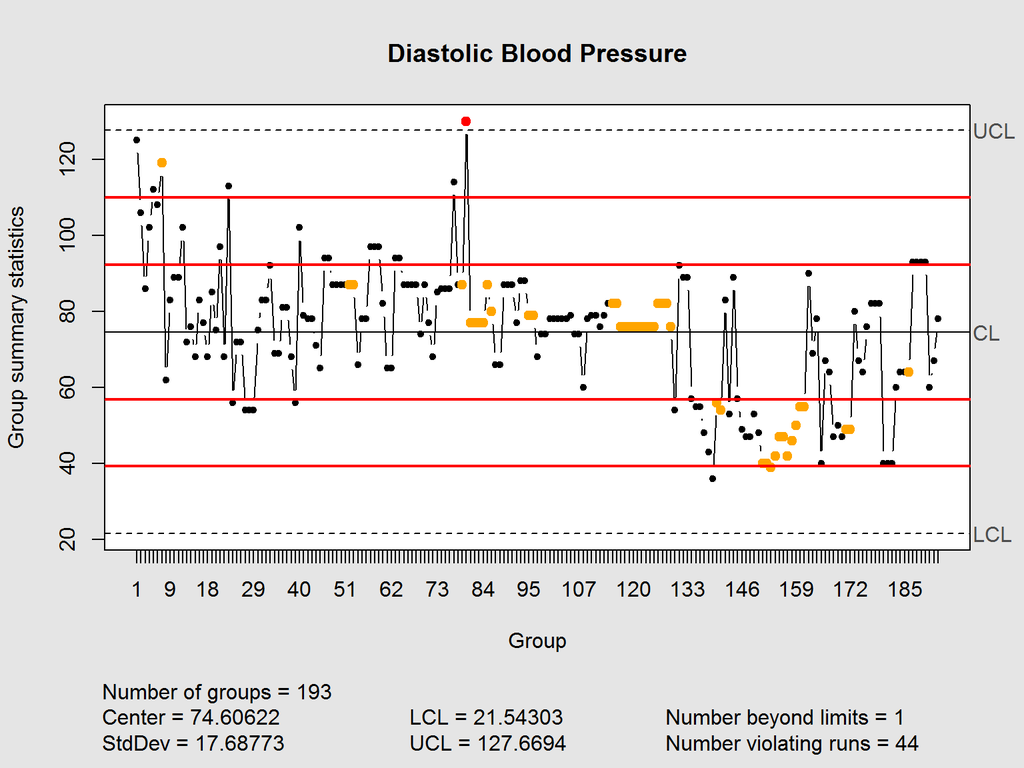

```
## $beyond.limits
## [1] 80
##
## $violating.runs
##  [1]   7  52  53  79  80  81  82  83  84  85  86  95  96 115 116 117 118
## [18] 119 120 121 122 123 124 125 126 127 128 129 140 141 151 152 153 154
## [35] 155 156 157 158 159 160 161 171 172 186
```

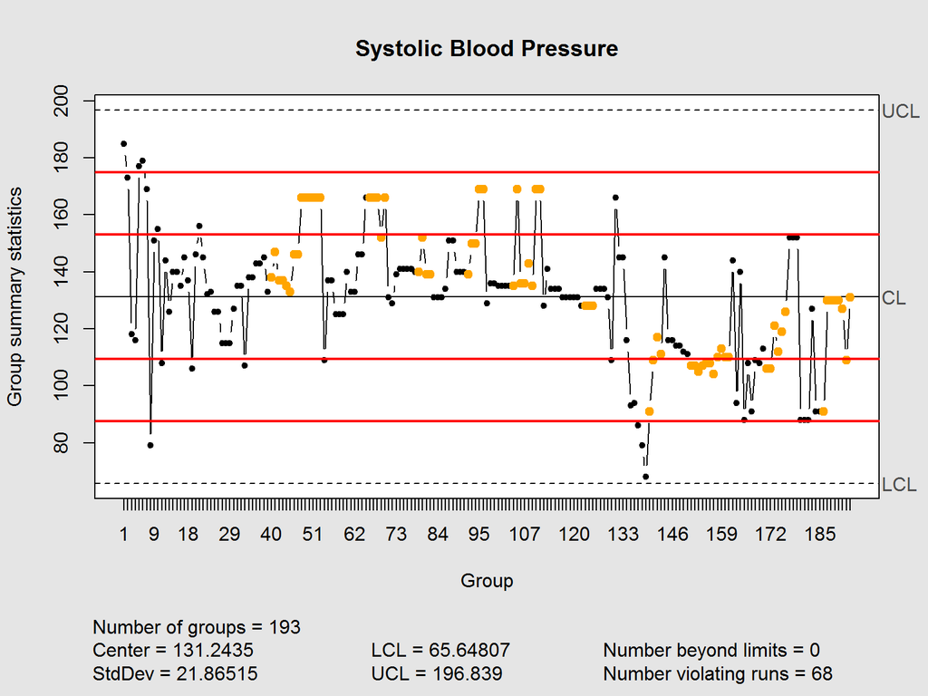

```
## $beyond.limits
## integer(0)
##
## $violating.runs
##  [1]  40  41  42  43  44  45  46  47  48  49  50  51  52  53  66  67  68
## [18]  69  70  79  80  81  82  92  93  94  95  96 104 105 106 107 108 109
## [35] 110 111 123 124 125 140 141 142 143 151 152 153 154 155 156 157 158
## [52] 159 160 161 171 172 173 174 175 176 186 187 188 189 190 191 192 193
```

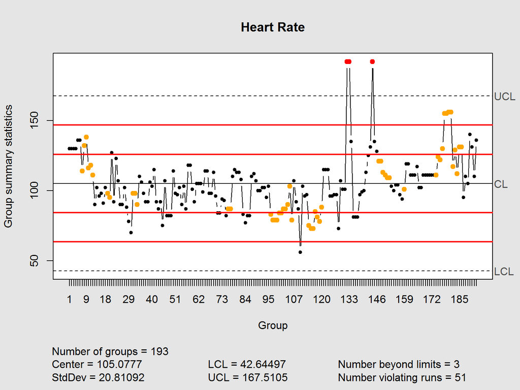

```
## $beyond.limits
## [1] 132 133 144
##
## $violating.runs
##  [1]   7   8   9  10  11  12 147 148 149 150 151 152 174 175 176 177 178
## [18] 179 180 181 182 183 184 185 186  19  20  31  32  33  76  77  96  97
## [35]  98  99 100 101 102 103 104 105 106 114 115 116 117 118 119 120 159
```

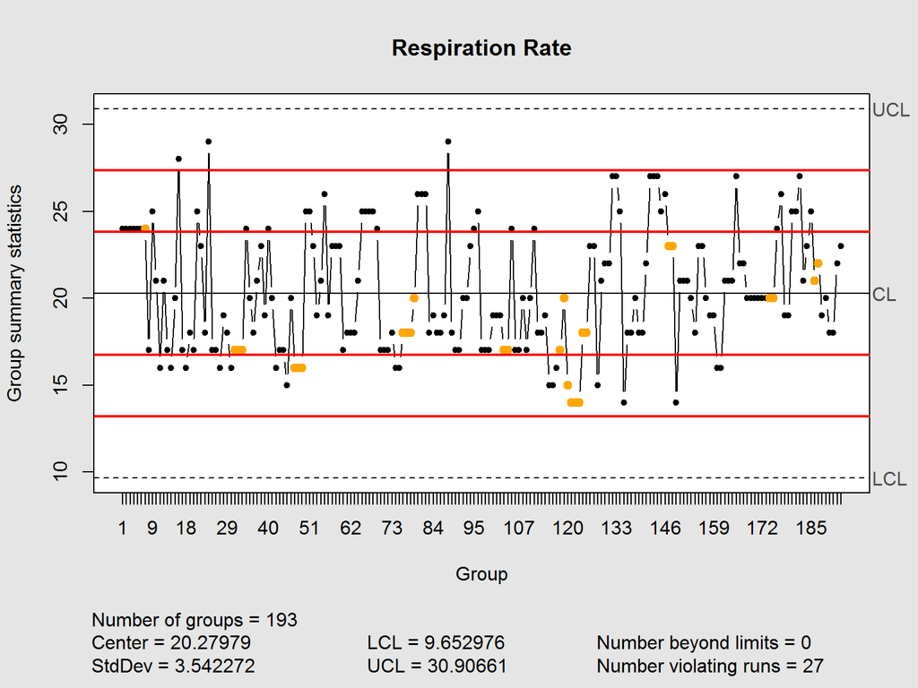

```
## $beyond.limits
## integer(0)
##
## $violating.runs
##  [1]   7 147 148 186 187  31  32  33  47  48  49  76  77  78  79 103 104
## [18] 118 119 120 121 122 123 124 125 174 175
```

- The indices of points beyond normal limits and triggering one of the Nelson Rules are highlighted in some form of a “red” and “orange” color respectively.
- Disregarding the fact that at certain moments there is a wide gap in terms of time difference from one observation to the next. As such, the results are plotted sequentially as they are observed.
- Tne final step is to find innovative ways of quantifying these results in a manner that can be integrated into the implemented model’s analysis with the end goal of detecting at-risk patients a few hours ahead of time.

# References

Sax Frederic L, C.M.E., Medical Patients at high risk for catastrophic deterioration. Crit Care Med, 1987. 15: p. 510-15.

Smith AF, W.J., Can some in-hospital cardio-respiratory arrests be prevented? A prospective survey. Resuscitation, 1998. 37: p. 133-7.

Subbe, C.P., et al., Validation of a modified Early Warning Score in medical admissions. Qjm, 2001. 94(10): p. 521-6.

Gardner-Thorpe, J., et al., The value of Modified Early Warning Score (MEWS) in surgical in-patients: a prospective observational study. Ann R Coll Surg Engl, 2006. 88(6): p. 571-5.

Odetola, F.O., A. Gebremariam, and G.L. Freed, Patient and hospital correlates of clinical outcomes and resource utilization in severe pediatric sepsis. Pediatrics, 2007. 119(3): p. 487-94.

Parshuram Christopher S, H.J., Middaugh Kristen, Development and initial validation of the Bedside Paediatric Early Warning System score. Crit Care Forum, 2009. 13(4): p. 1-10.

Monaghan, A., Detecting and managing deterioration in children. Paediatric Nurs, 2005. 17(1): p. 32-5.

Tucker KM, B.T., Baker RB, Demeritt B, Vossmeyer MT, Prospective evaluation of a pediatric inpatient early warning scoring system. J Spec Pediatr Nurs, 2009. 14(2): p. 79-85.

Skaletzky SM, Raszynski A, Totapally BR. Validation of a modified pediatric early warning system score: a retrospective case-control study. Clin Pediatr (Phila). 2012 May;51(5):431-5. doi: 10.1177/0009922811430342. Epub 2011 Dec 8. PubMed PMID: 22157421.

Mitchell TM. Machine learning. New York: McGraw-Hill; 1997. xvii, 414 p.

Michalski RSa, Carbonell JG, Mitchell TM, Anderson JR. Machine learning : an artificial intelligence approach. Palo Alto, Calif.: Tioga Pub. Co.; 1983. v. p.

Bezdek JC. Pattern Analysis. In: Pedrycz W, Bonissone PP, Ruspini EH, editors. Handbook of Fuzzy Computation. Bristol: Institute of Physics; 1998. p. F6.1.-F6..20.

Wu MC, Lee S, Cai T, Li Y, Boehnke M, Lin X. Rare-variant association testing for sequencing data with the sequence kernel association test. Am J Hum Genet. 2011;89I:82-93.

Lunardon, N., Menardi, G., & Torelli, N. (n.d.). ROSE: A Package for Binary Imbalanced Learning. Retrieved from https://journal.r-project.org/archive/2014-1/menardi-lunardon-torelli.pdf

Compare The Performance of Machine Learning Algorithms in R - Machine Learning Mastery. (n.d.). Retrieved June 21, 2017, from http://machinelearningmastery.com/compare-the-performance-of-machine-learning-algorithms-in-r/